# Lab 6: Class Exercises

Data Visualiaiton - DS4073

2023/11/21

# Class exercises

#### Please design your visualizations. Submit the `.zip` file that contains the dataset, `.rmd`, `.html` files to iSpace.

The “insurance.csv” file collects the personal medical cost in US. You can download this dataset on iSpace. The dataset contains 7 variables:

- age: age of primary beneficiary
- sex: insurance contractor gender, female, male
- bmi: Body mass index, providing an understanding of body, weights that are relatively high or low relative to height, objective index of body weight (kg / $m^2$) using the ratio of height to weight, ideally 18.5 to 24.9
- children: Number of children covered by health insurance / Number of dependents
- smoker: Smoking
- region: the beneficiary’s residential area in the US, northeast, southeast, southwest, northwest.
- charges: Individual medical costs billed by health insurance

**Please abstract two tasks from the dataset and design the visualizations for your tasks according to the following requirements.**

**Requirements:**

1. Please consider visualization design principles (Lecture 2 - 5), e.g. the expressiveness principle and effectiveness principle. Explain your design ideas.
2. Please create at least one multivariate graph.
3. There is no unique solution for the visualization. Please try your best to make your visualization informative and attractive.
4. Please explain the results, i.e. what insights can you extract from your visualizations?

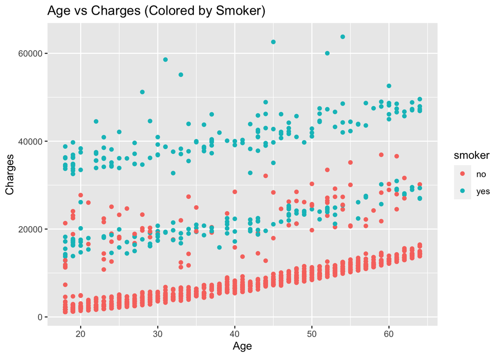

```r
# Write your code here
library(ggplot2)
data <- read.csv("insurance.csv")

# Create scatter plot to represent the relationship between Age an Charges.
# Group data according to Smoker.
ggplot(data, aes(x = age, y = charges, color = smoker)) +
  geom_point() +
  labs(title = "Age vs Charges (Colored by Smoker)", x = "Age", y = "Charges")
```

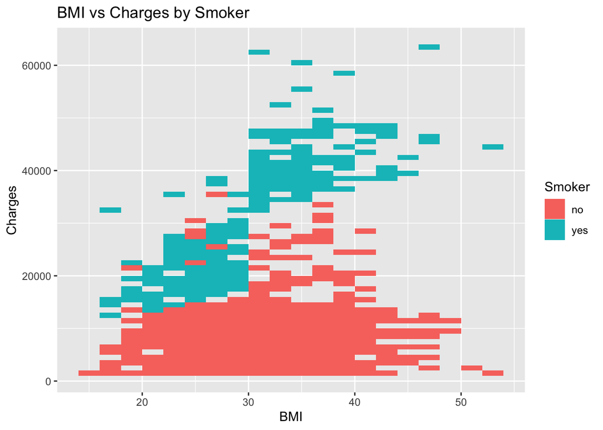

```r
# Create heatmap to represent the relationship between BMI and Charges.
# Group data according to Smoker.
ggplot(data, aes(x = bmi, y = charges, fill = smoker)) +
  geom_bin2d(binwidth = c(2, 1000)) +
  labs(title = "BMI vs Charges by Smoker", x = "BMI", y = "Charges") +
  scale_fill_discrete(name = "Smoker")
```

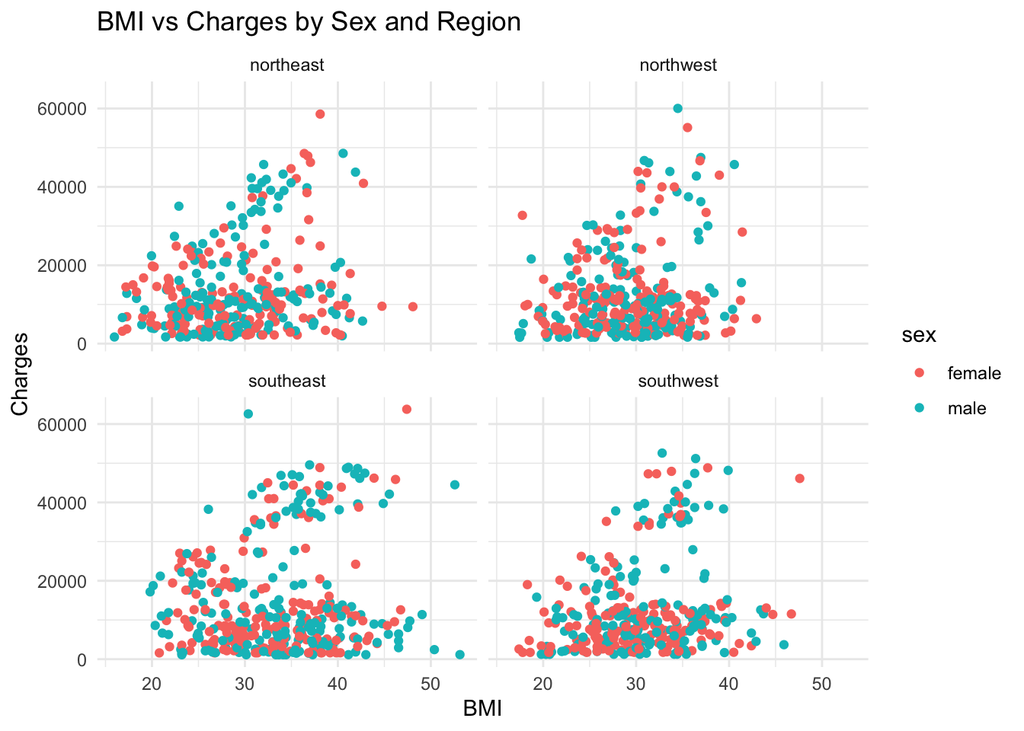

```r
ggplot(data, aes(x = bmi, y = charges, color = sex)) +
  geom_point() +
  facet_wrap(~region) +
  labs(title = "BMI vs Charges by Sex and Region", x = "BMI", y = "Charges") +
  theme_minimal()
```

**Please write your explanations below:**  
1. Design Idea: (1) Encoding variables effectively: here I use visual encodings like color (for sex), position (for BMI and charges), and facets (for region) to represent multiple variables without overcrowding the plot. (2) Clarity in representation: The chosen plot type (scatter plot) effectively represents the relationships between BMI and charges, while color distinguishes between sexes. Faceting adds depth by showing regional differences. (3) Avoiding clutter: Careful use of elements prevents the plot from becoming too crowded, ensuring that the viewer can interpret the data without confusion. (4) Effectiveness Principle: To ensure effectiveness, I use Clear labeling and titles, and use context and relevance to help people understand how charges relate to BMI across regions and sexes.